# 8. Ensamblaje de genomas

## Objetivos

- ¿Para qué sirve ensamblar el genoma?
- ¿Qué datos hacen falta?
- ¿Cuál es la estrategia básica?
- ¿Cómo se evalúa la calidad del ensamblaje?

# Introducción

## Contexto

- Poryectos de secuenciación importantes:
  - [Earth Biogenome Project](https://www.earthbiogenome.org/)
  - [Darwin Tree of Life](https://www.darwintreeoflife.org/)
- Tecnologías de secuenciación mejoradas:
  - Lecturas ultra-largas de Oxford Nanopore (<100 Kb, Q21)
  - Lecutras HiFi de PacBio (<25 Kb, Q33)
  - [Roche SBX?](https://diagnostics.roche.com/global/en/products/product-category/lab-type/sequencing/ngs-next-generation-sequencing-platform.html)

## PacBio HiFi

[How HiFi Works](https://www.youtube.com/watch?v=7yYPHatccgw)

## Definiciones

- **Ensamblaje**: Reconstrucción de la secuencia completa del genoma de *un organismo* mediante la ordenación de las secuencias de fragmentos de ADN.
- **Cóntigo**: Secuencia contínua que forma parte del ensamblaje.
- **Supercóntigo** (*scaffold*): Secuencia formada por más de un cóntigo cuando se conoce el orden en el que están ligados, aunque se desconozcan partes de las secuencias entre ellos.
- **Haplótigo**: Cóntigo que representa un solo haplotipo, cuando el ensamblaje es *dual* o *faseado*.
- **Ensamblaje dual** o faseado: Ensamblaje en el que se distinguen las secuencias que provienen de cada haplotipo de un organismo diploide (o poliploide). Lo contrario sería un **ensamblaje colapsado**.

# Desafíos del ensamblaje

## Elementos repetitivos

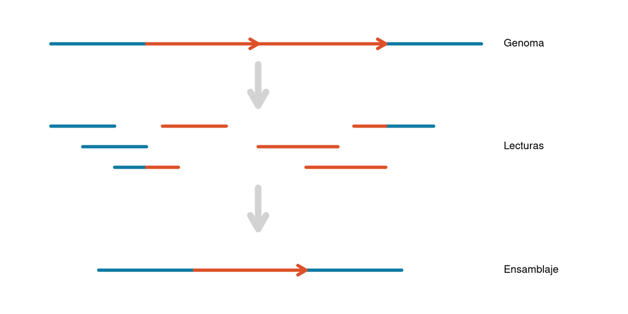

## Heterocigosidad

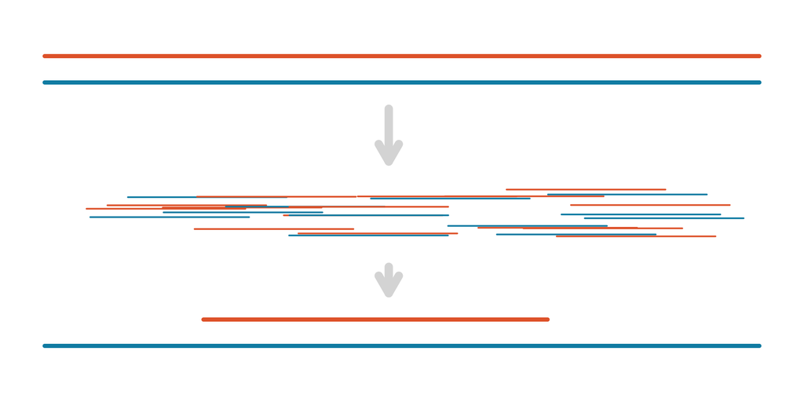

## Poliploidia

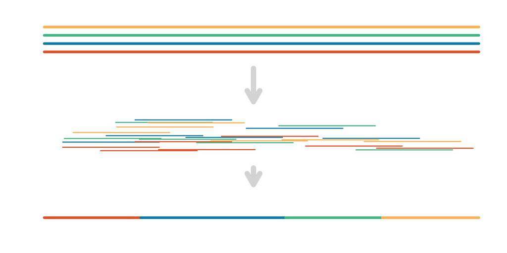

## Otros desafíos

- Los errores de secuenciación en las lecturas pueden confundirse con la heterocigosidad.
- La heterocigosidad puede incluir variantes estructurales que introducen ambigüedad en el ensamblaje.
- El alto contenido en repeticiones exige el uso de lecturas largas.
- Cuanto mayor es el genoma, mayor esfuerzo de secuenciación necesita.
- Cuando el organismo es muy pequeño (y no clonal) el ADN de partida será poliploide o demasiado escaso.

# Procedimiento

## Control de calidad

- Sólo lecturas de alta calidad, con bajo contenido de errores.
- Programas aptos para lecturas largas: fastp, NanoPlot, FiltLong,

## Estimación del tamaño del genoma

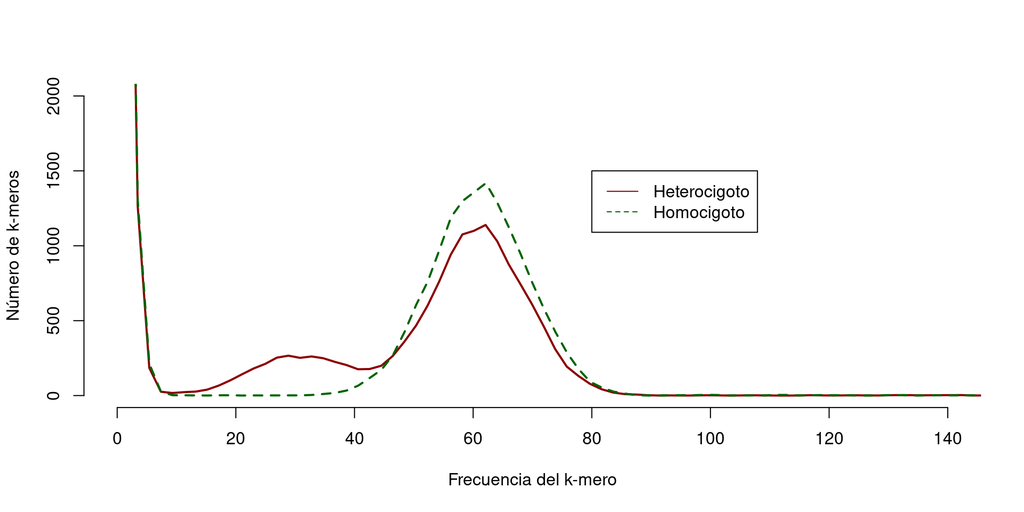

(Liao, Zhu, and Liu 2024)

## Estimación del tamaño del genoma

En un genoma de tamaño $G$ puede haber $G - k + 1$ palabras de longitud $k$. Si $G >> k$, puede haber casi $G$ palabras. Entre todas las lecturas de la secuenciación del genoma puede haber un gran número $n$ de palabras (o *k-meros*) diferentes de longitud $k$, cada uno de los cuales aparece con una frecuencia $x_i$. La frecuencia media $C$, es la cobertura media, el número de veces que en término medio se ha secuenciado cada nucleótido. Si entre todas las lecturas suman una longitud total $N = \sum_{i=1}^nx_i$, el tamaño del genoma debería ser $\hat{G} = \frac{N}{C}$.

## Corrección de errores

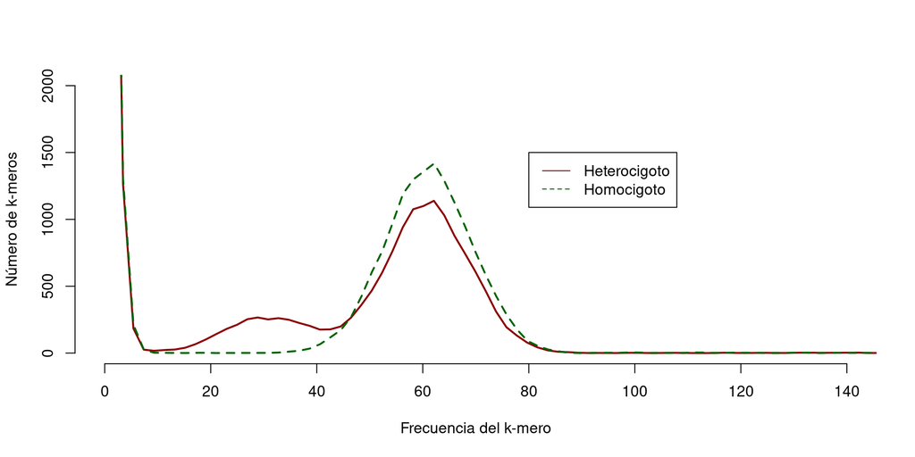

(Liao, Zhu, and Liu 2024)

## Corrección de errores

Las palabras que aparecen muy pocas veces deben contener errores y pueden corregirse por comparación a las palabras que más se les parezcan.

## Grafo de fragmentos

[figure not shown]

(Myers 2005).

Conectamos cada lectura con aquellas con las que puede alinearse.

## Grafo de fragmentos

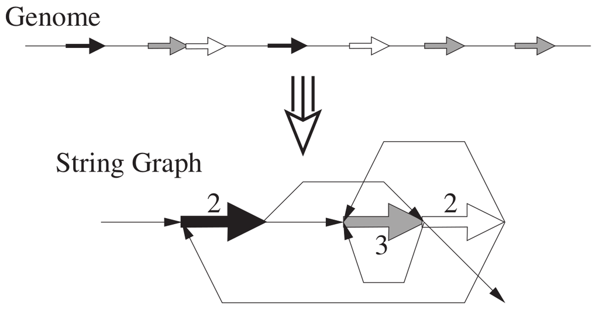

(Myers 2005)

## Grafo de fragmentos

[figure not shown]

(Nurk et al. 2022)

## Procesamiento del grafo

- Simplificación del grafo.
- Eliminación (o no) de duplicados por heterocigosidad.
- Convertir los contigs del [grafo](https://github.com/GFA-spec/GFA-spec/blob/master/GFA1.md) a FASTA.

## Añadir información adicional

- Datos adicionales
  - Datos Hi-C.
  - Mapaje óptico.
  - *Trio binning*
- Formación de supercóntigs (*scaffolds*)

## Evaluación del ensamblaje

- Estadísticos de contigüidad:
  - N50: Longitud del cóntigo más pequeño entre los cóntigos más largos que acumulan el 50% de la longitud total del ensamblaje.
  - L50: número más pequeño posible de cóntigos que suman al menos el 50% de la longitud del ensamblaje.
- Contenido génico: BUSCO

[figure not shown]

# Principales programas

## [Hifiasm](https://github.com/chhylp123/hifiasm)

- Optimizado para lecturas de alta calidad (HiFi) de PacBio.

## Flye

## Recursos y referencias

- [rcac-bioinformatics](https://rcac-bioinformatics.github.io/genome-assembly/assembly-evaluation.html)
- [Genomes on a Tree](https://goat.genomehubs.org/)

Liao, Xiangyu, Wufei Zhu, and Chaoyun Liu. 2024. “A High-Precision Genome Size Estimator Based on the k-Mer Histogram Correction.” *Frontiers in Genetics* 15. https://doi.org/10.3389/fgene.2024.1451730.

Myers, E. W. 2005. “The Fragment Assembly String Graph.” *Bioinformatics* 21 (suppl_2): ii79–85. https://doi.org/10.1093/bioinformatics/bti1114.

Nurk, Sergey, Sergey Koren, Arang Rhie, Mikko Rautiainen, Andrey V. Bzikadze, Alla Mikheenko, Mitchell R. Vollger, et al. 2022. “The Complete Sequence of a Human Genome.” *Science* 376 (6588): 44–53. https://doi.org/10.1126/science.abj6987.